# NBA

### Ahora analizaremos los supuestos que no se cumplen para el modelo de regresion multilineal simple

#### Vamos a analizar la normalidad con QQ-plots

Un QQ-plots (quantile vs quantile plots) es una representación gráfica, que sirve para comparar dos distribuciones y ver si coinciden. En realidad, para comprobar si un conjunto de datos muestrales están generados por una distribución teórica como la normal

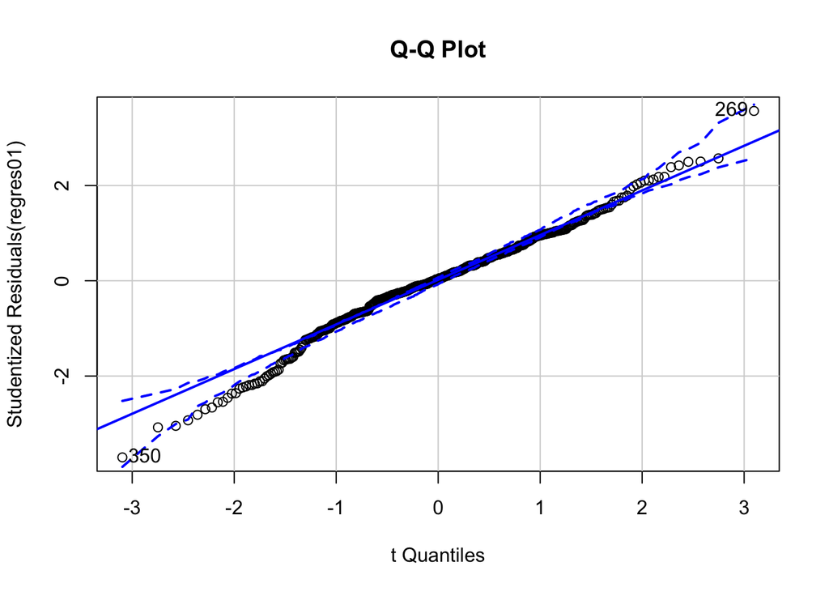

```
## [1] 269 350
```

```r
qqPlot(regres01, labels = row.names(nba), id.method = "identify",
       simulate = TRUE, main = "Q-Q Plot")
```

#### Vemos el histograma con su funcion de densidad

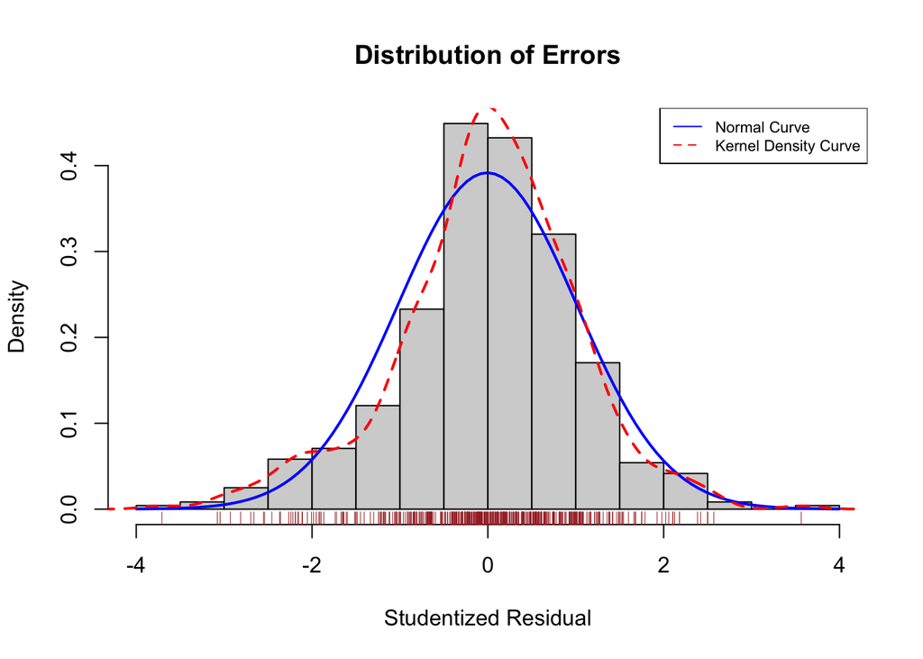

```r
residplot <- function(fit, nbreaks=20) {
  z <- rstudent(fit)
  hist(z, breaks=nbreaks, freq=FALSE,
       xlab="Studentized Residual",
       main="Distribution of Errors")
  rug(jitter(z), col="brown")
  curve(dnorm(x, mean=mean(z), sd=sd(z)),
        add=TRUE, col="blue", lwd=2)
  lines(density(z)$x, density(z)$y,
        col="red", lwd=2, lty=2)
  legend("topright",
         legend = c( "Normal Curve", "Kernel Density Curve"),
         lty=1:2, col=c("blue","red"), cex=.7)
}

residplot(regres01)
```

#### Linealidad

Se grafican los valores ajustados con respecto a los predictores, si no hay problemas de linealidad se obtiene un recta sobre las que se representan los puntos.

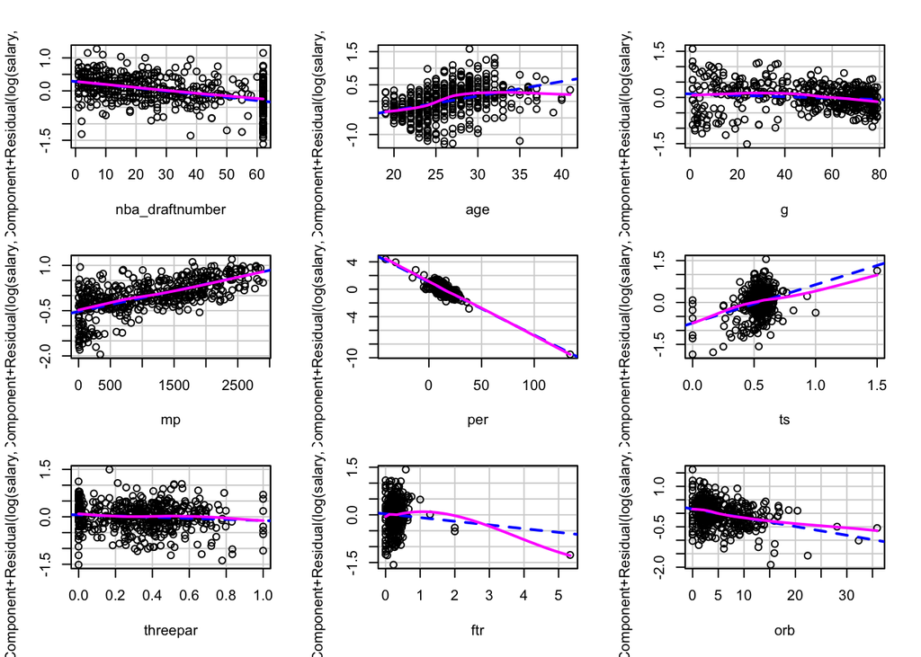

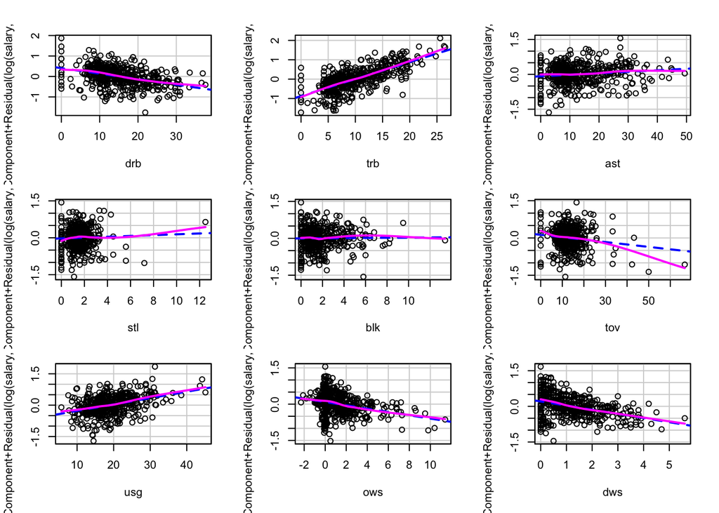

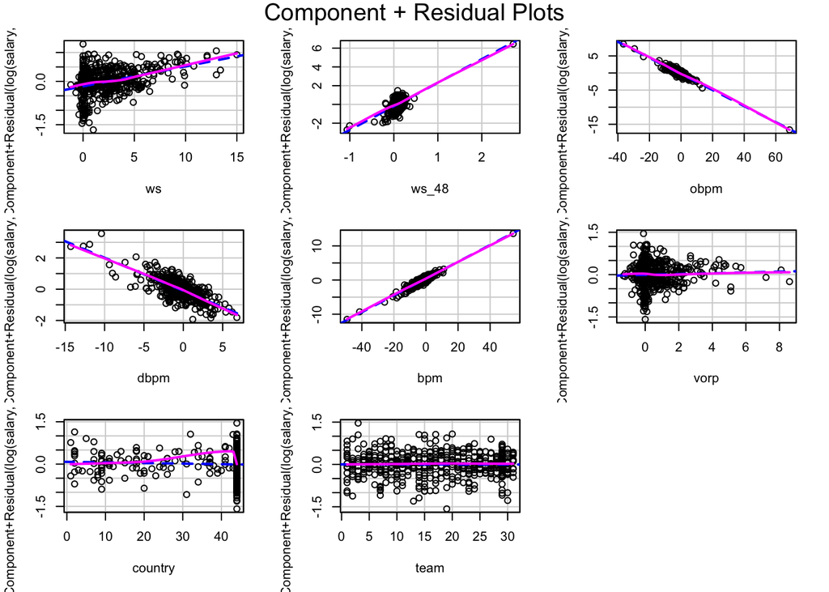

```r
crPlots(regres01)
```

#### Multicolinealidad

Es la existencia de alta correlación entre los predictores puede producir problemas de imprecisión de los estimadores (las varianzas de los estimadores son mayores de lo que deberían ser). Así, los intervalos de confianza son muy anchos, hay dificultad para interpretar los coeficientes y se tiende a no rechazar las hipótesis nula de significación.

##### Método del Factor de Inflación de la Varianza

```r
vif(regres01)
```

```
## nba_draftnumber             age               g              mp             per
##        1.345441        1.091872        7.035190       14.407427      111.850322
##              ts        threepar             ftr             orb             drb
##        6.168451        5.336738        1.280808      317.326699      684.613333
##             trb             ast             stl             blk             tov
##     1440.410709        3.470547        3.213614        5.321115        1.943902
##             usg             ows             dws              ws           ws_48
##        6.937015     1329.993275      405.190589     2684.737723       69.252839
##            obpm            dbpm             bpm            vorp         country
##    10533.312116     2308.422567    12935.991592       11.601943        1.097606
##            team
##        1.070125
```

```r
sqrt(vif(regres01)) > 2
```

```
## nba_draftnumber             age               g              mp             per
##           FALSE           FALSE            TRUE            TRUE            TRUE
##              ts        threepar             ftr             orb             drb
##            TRUE            TRUE           FALSE            TRUE            TRUE
##             trb             ast             stl             blk             tov
##            TRUE           FALSE           FALSE            TRUE           FALSE
##             usg             ows             dws              ws           ws_48
##            TRUE            TRUE            TRUE            TRUE            TRUE
##            obpm            dbpm             bpm            vorp         country
##            TRUE            TRUE            TRUE            TRUE           FALSE
##            team
##           FALSE
```

```r
# tenemos problemas de multicolinealidad en ts, trb, usg, obpm, threepar, ows, dbpm, g, dws, bpm, mp, orb, blk, ws, vorp, per, drb, ws_48
```

#### Outliers

##### Observaciones anómalas

1 - Atípicos: Una observación es atípica si el residuo asociado es grande. 2 - Extrema o Apalancada: Una observación es extrema (o potencialmente influyente o apalancada) si se encuentra apreciablemente alejada del resto de observaciones de la muestra. 3 - Influyente: Una observación es influyente si la presencia de dicha observación en la muestra altera significativamente algún aspecto de la estimación del modelo.

###### Valores Atípicos

- Identificamos los valores atípicos mediante un Bonferroni p-values. En este caso solo contrasta el mayor de los residuos, si se rechaza que sea atípico se concluye que no hay atípicos.
- También se puede realizar un gráfico de los residuos estandarizados con ±2σ.

```r
outlierTest(regres01)
```

```
## No Studentized residuals with Bonferroni p < 0.05
## Largest |rstudent|:
##      rstudent unadjusted p-value Bonferroni p
## 350 -3.708135         0.00023468      0.11288
```

###### Valores extremos

- Para determinar valores extremos, se calcula el `hat statistic`, siendo la media *p/n* donde p es el número de parámetros estimados y n el tamaño muestral. Las observaciones con un valor (2 o 3 veces la media) hat alto se consideran extremas.

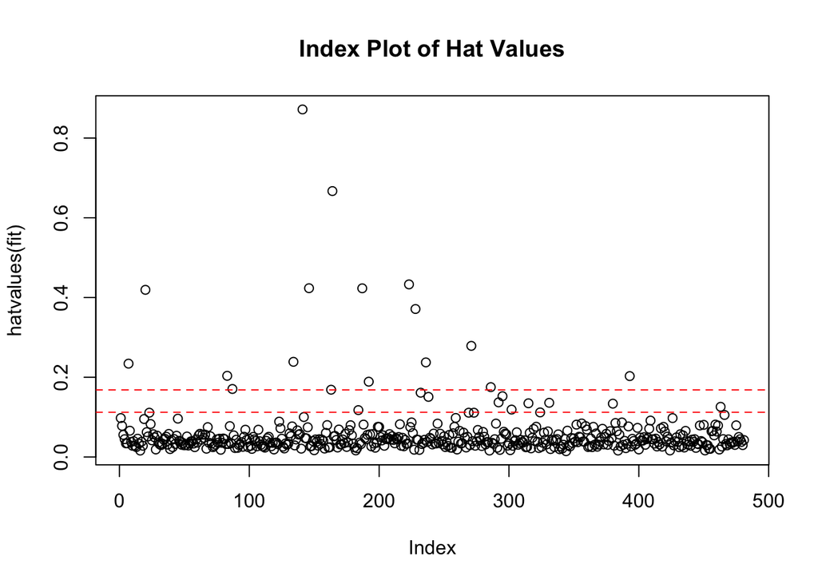

```
## integer(0)
```

```r
hat.plot <- function(fit) {
  p <- length(coefficients(fit))
  n <- length(fitted(fit))
  plot(hatvalues(fit), main="Index Plot of Hat Values")
  abline(h=c(2,3)*p/n, col="red", lty=2)
  identify(1:n, hatvalues(fit), names(hatvalues(fit)))
}
hat.plot(regres01)
```

###### Valores Influyentes

Hay dos métodos par identificar observaciones influyentes:

- La distancia de Cook (D-estadístico)
- Gráficos added variable

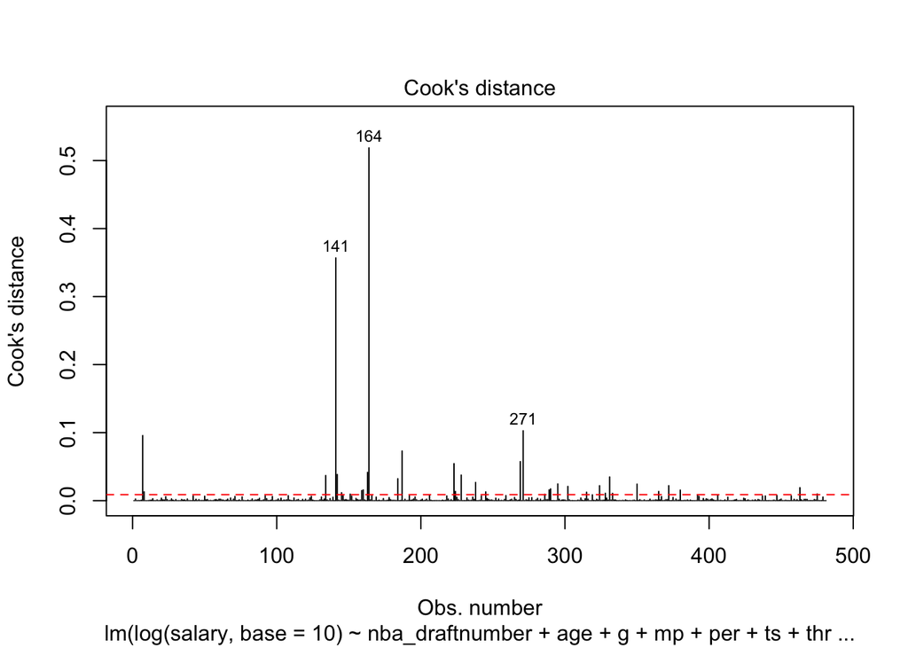

```r
# Cooks Distance D
# identify D values > 4/(n-k-1)
cutoff <- 4/(nrow(nba)-length(regres01$coefficients)-2)
plot(regres01, which=4, cook.levels=cutoff)
abline(h=cutoff, lty=2, col="red")
```

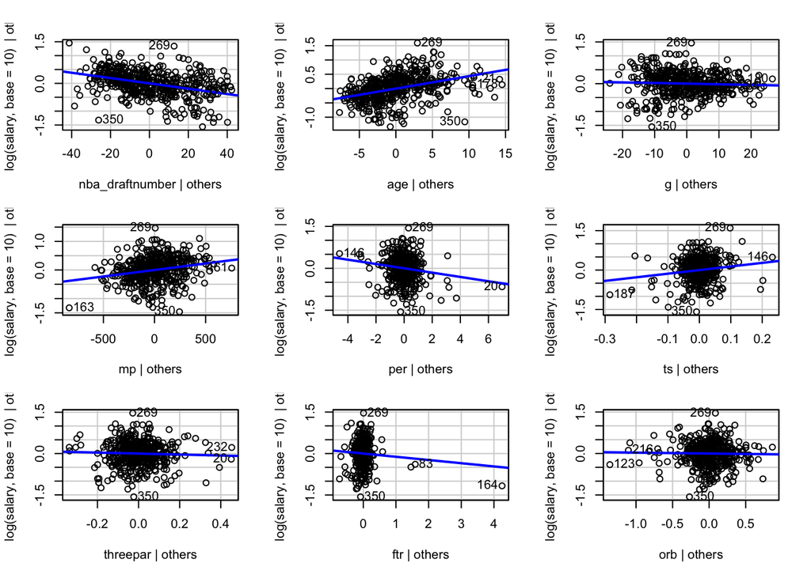

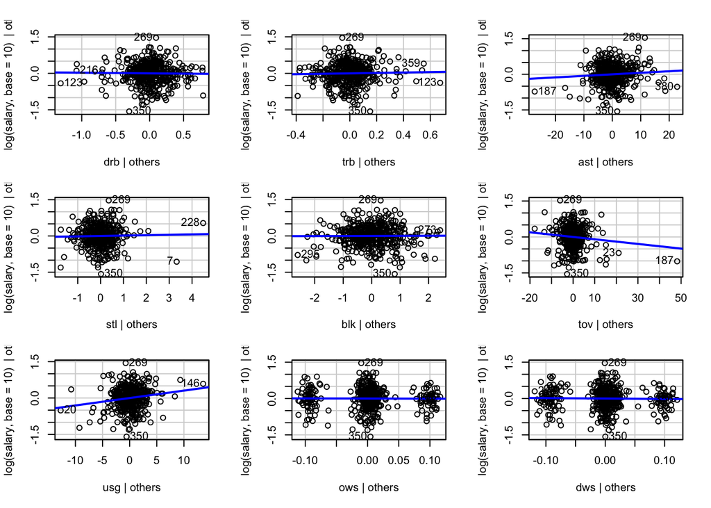

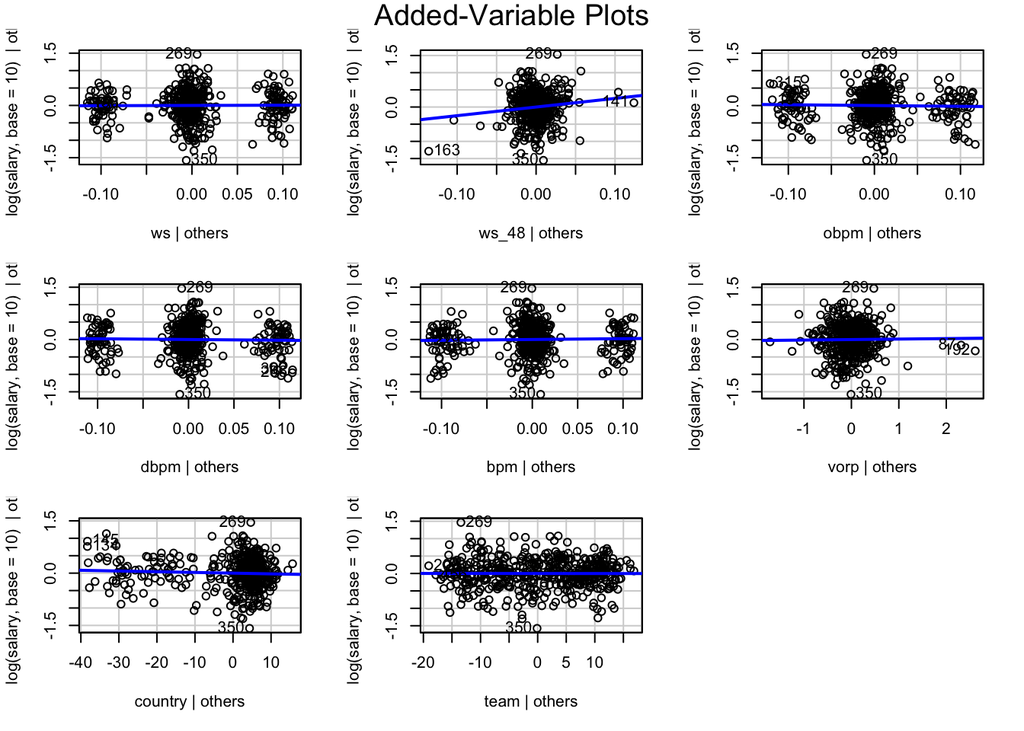

```r
# Added variable plots
# add id.method="identify" to interactively identify points
avPlots(regres01, ask = FALSE, id.method = "identify")
```

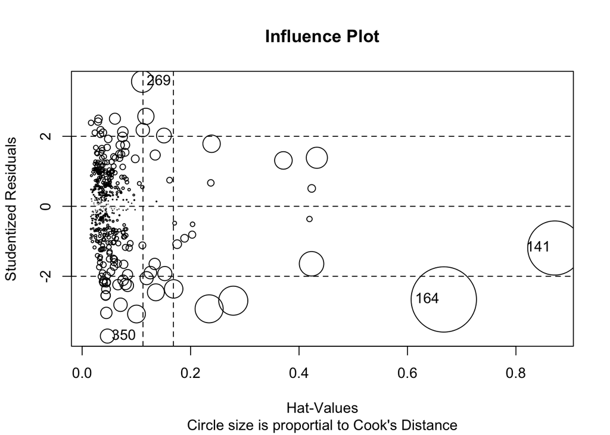

```
##       StudRes        Hat      CookD
## 141 -1.191196 0.87172295 0.35680540
## 164 -2.661516 0.66701136 0.51858186
## 269  3.565514 0.11112914 0.05738619
## 350 -3.708135 0.04666799 0.02424899
```

```r
# Influence Plot
influencePlot(regres01, id.method="identify", main="Influence Plot",
              sub="Circle size is proportial to Cook's Distance" )
```